# ICD10gm

24. März 2021 | AGENS-Methodenworkshop 2021

## Über mich

- Statistiker bei der Kassenärztlichen Vereinigung Bayerns
  - Versorgungsanalysen und -forschung mit Routinedaten
- Externe Dissertation unter Verwendung der KVB-Routinedaten
  - Betreuer:  
    Prof. Paul Enck (Universitätsklinikum Tübingen)  
    Prof. Antonius Schneider (TU München)
  - Funktionelle Erkrankungen in der ambulanten Versorgung
- Autor des R-Packages `ICD10gm`
  - Bereitstellung der ICD-10-GM-Metadaten für die Versorgungsforschung
  - Strategien für die Auswertung von Verlaufsdaten
  - Dokumentation: https://edonnachie.github.io/ICD10gm

## Motivation

*How it started:*

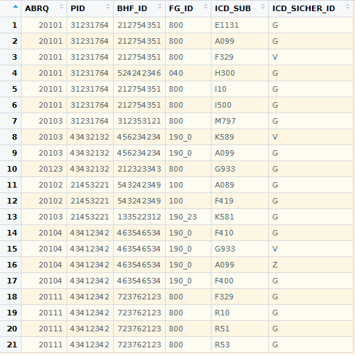

*How it's going:*

[figure not shown]

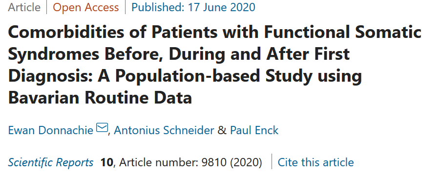

## Die ICD-10 Klassifikation

Im Kern des Packages stehen vier Tabellen mit ICD-10-Metadaten für die Jahre 2004–2021:

- `icd_meta_codes`: Endstellige Schlüsselnummer mit Labels und erweiterten Metadaten (z. B. ist der Code meldepflichtig oder endstellig?)
- `icd_meta_blocks`: Definition der aus mehreren angrenzenden Codes gebildeten ICD-Blöcke
- `icd_meta_chapters`: Labels für die 22 ICD-10-Kapitel
- `icd_meta_transition`: Überleitungen von einer ICD-10-GM-Version ins nächste Version

Quelle: Bundesinstitut für Arzneimittel und Medizinprodukte. Die Bereitstellung der Daten in dieser Form ist erlaubt!

## Stuktur der ICD-10-Klassifikation

Hierarchische Struktur mit 3–5 Stellen:

1. Eine Buchstabe kodiert das Kapitel (Ätiologie)  
   - F: Psychische und Verhaltensstörungen
   - G: Krankheiten des Nervensystems
2. Zwei numerische Stellen bilden die "dreistellige" Diagnose
   - E11: Typ-2-Diabetes
   - Z00: Gesundheitsuntersuchung ohne Diagnose
3. Zwei weitere numerische Stellen ermöglichen eine spezifische Kodierung
- E11.31: Typ-2-Diabetes mit Augenkomplikationen, entgleist

## Zwei Strategien für die Datenabfrage

1. **Codes unmittelbar im Skript aufnehmen**

```sql
select * from diagnosen
where icd = 'E11' and icd_sicher_id = 'G'
```

2. **Trennung von Auswertungslogik und Programmcode**

- Externe Code-Liste (z.B. csv/Excel)
- Programmcode referenziert diese Liste
- Vorteil: Übersichtlich, transparent, weniger fehleranfällig

```sql
select * from diagnosen
inner join meta_icd using (JAHR, ICD_SUB, ICD_SICHER_ID)
```

## Spezifikation einer Code-Liste

Ziel ist eine kompakte Spezifikation der relevanten Codes und Labels:

1. Spezifikation wird immer "nach Rechts" erweitert
   - Ausnutzung der hierarchischen Struktur
2. Weitere Attribute können in der Spezifikation aufgenommen werden
   - Gruppierungsmerkmal für die Zusammenführung von Diagnosen (z. B. Charlson-Diagnosen, Condition Categories)
   - Zusatzkennzeichen für die Diagnosesicherheit im ambulanten Bereich
   - Labels zur Verwendung in Abbildungen usw.

## Beispiel: Charlson Comorbidities

### 1. Spezifikation der Codes

Charlson-Komorbiditäten in der [Version der Royal College of Surgeons](https://doi.org/10.1002/bjs.6930):

```r
charlson <- readr::read_csv2("charlson_rcs.dat")

filter(charlson, Disease_Category == "Cerebrovascular disease")
```

```
## # A tibble: 3 x 2
##   Disease_Category        ICD_SPEC
##   <chr>                   <chr>
## 1 Cerebrovascular disease G45
## 2 Cerebrovascular disease G46
## 3 Cerebrovascular disease I6
```

## Beispiel: Charlson Comorbidities

### 2. Ermittlung aller zugehörigen Codes (`icd_expand`)

```r
spec_charlson <- ICD10gm::icd_expand(charlson, year = 2020,
  col_meta = "Disease_Category", col_icd = "ICD_SPEC")

subset(spec_charlson,
       Disease_Category == "Cerebrovascular disease")[1:5, c(1:3,6:7)]
```

```
## # A tibble: 5 x 5
##   icd_spec Disease_Category         year icd_normcode icd_sub
##   <chr>    <chr>                   <int> <chr>        <chr>
## 1 G45      Cerebrovascular disease  2020 G45          G45
## 2 G45      Cerebrovascular disease  2020 G45.0        G450
## 3 G45      Cerebrovascular disease  2020 G45.02       G4502
## 4 G45      Cerebrovascular disease  2020 G45.03       G4503
## 5 G45      Cerebrovascular disease  2020 G45.09       G4509
```

## Erkennung von ungültigen Codes

```r
ICD10gm::is_icd_code(c("A09.9", "A099", "A09.9-"))
```

```
## [1] TRUE TRUE TRUE
```

```r
ICD10gm::is_icd_code(c("AA9", "W12", "K58.3"), year = 2018)
```

```
## [1] FALSE FALSE FALSE
```

```r
ICD10gm::is_icd_code("K58.3", year = 2019)
```

```
## [1] TRUE
```

## Problem: Instabilität der ICD-10-GM

Die ICD-10-GM wird jährlich angepasst:

1. Aktualisierung der 4. und 5. Stelle entsprechend dem Stand der Medizin  
   Beispiel: Reizdarmsyndrom 2019
2. Neue Codes ermöglichen eine genauere Kodierung (Beispiel: Covid-19)
3. Diagnose wechselt in ein anderes Kapitel  
   Beispiel: nicht näher bezeichnete Gastroenteritis (K52.9 -> A09.9)

Folge: Eine ICD-10-Spezifikation kann nicht ohne Weiteres auf ein anderes Jahr übertragen werden!

## Beispiel: Charlson Comorbidities

### 3. Such nach problematischen Codes (`icd_showchanges`)

Die Funktion `icd_showchanges` prüft, ob das Ergebnis von `icd_expand` "instabilen" Codes beinhaltet:

```r
ICD10gm::icd_showchanges(spec_charlson) %>%
  filter(change_3 & year_from > 2004) %>%
  head(3)
```

```
##   year_from year_to icd_from icd_to automatic_forward automatic_backward
## 1      2005    2006   G45.01  I63.9                 A
## 2      2005    2006   G45.11  I63.9                 A
## 3      2005    2006   G45.21  I63.9                 A
##   change_5 change_4 change_3 change icd3 icd_kapitel
## 1    FALSE    FALSE     TRUE   TRUE  I63           I
## 2    FALSE    FALSE     TRUE   TRUE  I63           I
## 3    FALSE    FALSE     TRUE   TRUE  I63           I
```

## Beispiel: Charlson Comorbidities

### 4. Historisierung (`icd_history`)

```r
spec_charlson <- spec_charlson %>%
  ICD10gm::icd_history(years = 2004:2020)

filter(spec_charlson, Disease_Category == "Cerebrovascular disease") %>%
  head()
```

```
## # A tibble: 6 x 8
##   icd_spec Disease_Category   year icd3  icd_code icd_normcode icd_sub label
##   <chr>    <chr>             <int> <chr> <chr>    <chr>        <chr>   <chr>
## 1 G45      Cerebrovascular …  2018 G45   G45.09   G45.09       G4509   Arteria-…
## 2 G45      Cerebrovascular …  2017 G45   G45.19   G45.19       G4519   Arteria-…
## 3 G45      Cerebrovascular …  2018 G45   G45.19   G45.19       G4519   Arteria-…
## 4 G45      Cerebrovascular …  2019 G45   G45.39   G45.39       G4539   Amaurosi…
## 5 G45      Cerebrovascular …  2017 G45   G45.22   G45.22       G4522   Multiple…
## 6 G45      Cerebrovascular …  2018 G45   G45.13   G45.13       G4513   Arteria-…
```

## Beispiel: Ein "Real-World" Skript

```r
# Metadaten aufbereiten
icd_spec <- readr::read_csv("data/metadata/meta_icd.csv") %>%
  ICD10gm::icd_expand(year = 2020, col_meta = "DIAG_LABEL") %>%
  ICD10gm::icd_history(years = 2004:2020)

# Metadaten in die Datenbank schreiben
db <- dbConnect(...)
kvb::write_to_oracle(db, icd_spec, "META_ICD")

# DB-Abzug (etwas vereinfacht)
tbl(db, "FAKT_DIAGNOSEN") %>%
  inner_join(tbl(db, "DIM_ICD"), by = c("ABRQ", "ICD_KEY")) %>%
  inner_join(tbl(db, "META_ICD"), by = "ICD_SUB") %>%
  select(PID, DIAG_GROUP, ABRQ) %>%
  distinct()
```

## Fazit und Ausblick

- `ICD10gm`
  - Das ICD10gm-Package unterstützt die Auswertung der Routinedaten des deutschen Gesundheitswesens
    - Stellt die gesamten Metadaten ICD-10-GM für die Versorgungsforschung bereit
    - Löst ein zentrales Problem: Die Historisierung von ICD-10-GM-Codes
- Ausblick:
  - Übertragbarkeit der Ideen auf anderen Kodiersysteme (EBM, OPS)?
  - Besonders interessant erscheinen die neuen generischen R-Packages `encoder` und `decoder`.